# Bayesian Logistic Regression - NCAA case study

### Question 4: Where does the decision boundary locate for Logistic regression?

Logistic regression specifically sets the decision boundary at probability 0.5. Larger and smaller than this critical value (p = 0.5) will lead the logistic regression to predict success, and failure accordingly. Now let's create a plot from the trace data statistics to predict winning probability.

```
[Text(0.5, 1.0, 'Winning Probability vs Score'),
```

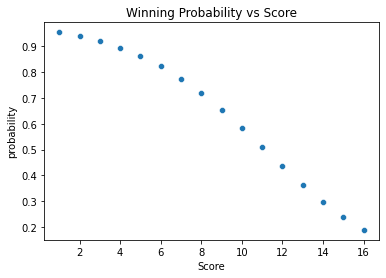

```python
# First let's plot the seed effect. We can create an integer sequence from 1 to 16.
seed = np.arange(1,17)

# Let's assume that at the end, a team would score 80 points in a playoff game. We can keep 80 points as constant,
# and substitute all effects on the formula to compute the log odds of winning the game.
log_odd = -2.846 + seed * -0.298 + 80 * 0.077

# Now plot a curve representing the change of winning probability by team's seed
sns.scatterplot(x = seed, y = 1/(1+np.exp(-log_odd))).set(title = "Winning Probability vs Score", xlabel = "Score", ylabel = "probability")

# Assuming a team obtaining 80 points as constant, we see that even the eleventh seed has a predicted
# winning probability larger than 0.5, thus predicting as winning a game.
# The decision boundary is therefore at seed = 11, where teams with lower seeds than 11 have the majority
# of time losing a game given the team scores 80 points.
```

```python
# We can use the trace data for seed variable, intercept and score variable, and add them together based on the
# dataset values. We now get the predicted log-odds for each data point.

round_of_64['log_odds'] = trace['intercept'].mean() + round_of_64['Seed'] * trace['seed'].mean() + trace['score'].mean() * round_of_64['Score']
```

```python
round_of_64.shape
# (2048, 12)
```

```
(2048, 12)
```

```python
round_of_64.head()
```

|  | Unnamed: 0 | Date | Round | Region | Winning Seed | Winning Score | Seed | Score | Outcome | Losing Seed | Losing Score | log_odds |
| --- | --- | --- | --- | --- | --- | --- | --- | --- | --- | --- | --- | --- |
| 0 | 0 | 3/14/85 | Round of 64 | East | 1.0 | 68.0 | 1 | 68 | 1 | NaN | NaN | 2.092105 |
| 1 | 1 | 3/14/85 | Round of 64 | East | 4.0 | 59.0 | 4 | 59 | 1 | NaN | NaN | 0.504170 |
| 2 | 2 | 3/14/85 | Round of 64 | East | 5.0 | 85.0 | 5 | 85 | 1 | NaN | NaN | 2.216790 |
| 3 | 3 | 3/14/85 | Round of 64 | East | 8.0 | 60.0 | 8 | 60 | 1 | NaN | NaN | -0.608074 |
| 4 | 4 | 3/14/85 | Round of 64 | Midwest | 1.0 | 96.0 | 1 | 96 | 1 | NaN | NaN | 4.256729 |

Awesome! In this video, we've established a Bayesian logistic regression model. We've diagnosed patterns related to the traceplot, autocorrelation plot, and plot the change of winning probability by increasing or decreasing certain variables. One good takeaway is that after obtaining the trace object, you should ensure that

- the posterior samples converge
- effective sample size is sufficiently large (>200)
- and posterior samples should not be largely autocorrelated

In the next video, we'll continue exploring the predictive power of Bayesian logistic regression.

# Video 3: Bayesian Logistic Regression - Classification Prediction

In this video, we'll explore the predictive ability of Bayesian logistic regression on NCAA games. Moving from the dataset where we've added the predictive log odds onto it, we can find out how accurately our Bayesian logistic regression model predicts the outcome of NCAA games.

### Question 5: What decision rule does Bayesian logistic regression implement?

In logistic regression, we make decision with a very straightforward rule:

- if a team has a positive log odd, we predict the team will win the NCAA game, so Outcome = 1, and
- if a team has a negative log odd, we predict the team will lose the game, so Outcome = 0

Note that log odd 0 has the same meaning of probability = 0.5, which you can verify simply by looking back at video 1.

### Question 6: What are typical metrics that Bayesian logistic regression uses for prediction?

In terms of metrics, let's define **True Positive, True Negative, False Positive, False Negative** based on the decision boundary of log_odd = 0. If you haven't heard of these four vocabularies,

- A true positive is an outcome where the model correctly predicts the winning team.
- A true negative is an outcome where the model correctly predicts the losing team.
- A false positive is an outcome where the model incorrectly predicts the winning team.
- A false negative is an outcome where the model incorrectly predicts the losing team.

There is a wikipedia reading if you are interested: https://en.wikipedia.org/wiki/Precision_and_recall

```python
# So we can use these concepts to compute the true positive, for those whose log odds is positive, and outcome is 1

true_positive = round_of_64[(round_of_64['Outcome'] == 1) & (round_of_64['log_odds'] > 0)].shape[0]
# and print the number of true positive outcomes
print("True Positive:", true_positive)

# Same for true negative, false positive, and false negatives.

true_negative = round_of_64[(round_of_64['Outcome'] == 0) & (round_of_64['log_odds'] < 0)].shape[0]
print("True Negative:", true_negative)

false_positive = round_of_64[(round_of_64['Outcome'] == 0) & (round_of_64['log_odds'] > 0)].shape[0]
print("False Positive:", false_positive)

false_negative = round_of_64[(round_of_64['Outcome'] == 1) & (round_of_64['log_odds'] < 0)].shape[0]
print("False Negative:", false_negative)

# So there are 803 true positive, 813 true negative, 211 false positive, and 221 false negative throughout.
# So we envision it's prediction can correctly identify around 80% of winning and losing competitors.
```

```
True Positive: 803
True Negative: 813
False Positive: 211
False Negative: 221
```

Based on the true positive, true negative, false positive and false negative, we've enough information to understand the goodness of model prediction. If we're more careful about predicting a winning team accurately, and hate the classification in which you misleadingly bet a team winning a game but it ends up losing, then we'd like to compute the **precision**. It's computed such that the number of true positives is compared against all positive predictions you've made.

$precision = \frac{True Positive}{True Positive + False Positive}$

But if we're more scrutinous on minimizing the predictions where we predict as losing but in fact it's winning, then we'd like to compute the **recall**. It's computed such that the number of true positives is compared against all predictions that should have been positive.

$recall = \frac{True Positive}{True Positive + False Negative}$

And finally for classification, the F-1 score tries to average off the precision and recall so that both concerns are treated equally important. And the formula of F-1 score is 2 times the product of precision and recall divided by the sum of precision and recall.

$F1 = \frac{2 * precision * recall}{precision + recall}$

```python
# Now we've learned the concept and the formula. Let's compute precision, recall, and F1 score

precision = true_positive / (true_positive + false_positive)
# and print it out
print("Precision:", precision)

recall = true_positive / (true_positive + false_negative)
print("Recall:", recall)

# F-1 score is equivalent to the harmonious average of precision and recall
f1_score = 2 * (precision * recall) / (precision + recall)
print("F-1 Score:", f1_score)

# Cool! If we know the team seed and the final score beforehand, we can make 80% of the game predictions
# correct. That does not mean we can use it to predict 2021 since this year is over. A brilliant thought
# is that we can use it to predict the next year NCAA march madness of 2022, assuming that the scoring
# pattern for winning and losing team stayed at the average value from 25-year historical figures.

# Question: What if we don't know anything, except for past statistics about the teams?
# How great shall we predict the game results before watching the game?
```

```
Precision: 0.7919132149901381
Recall: 0.7841796875
F-1 Score: 0.7880274779195289
```

There are still many aspects of Bayesian regression research we can explore on these wonderful topics. So far we've just discussed linear regression and logistic regression for TED talk prediction and NCAA winning probability and result predictions by looking at the posterior distribution. On the prediction side, we've used metrics such as precision, recall and F-1 score. There isn't any metric that is absolutely more useful than other metrics. But there are still many Bayesian methods that we should explore in the future. Already, let's move on to hypothesis testing in the next video! See you!

## Appendix A: Concept of Logistic Regression

There are many ways to select an appropriate decision boundary, a few of which were covered in this course earlier. So now let's take a look at this concept of an inverse link function.

- $\theta = f(\alpha + \beta x)$

The inverse link function takes the form given by linking the output of linear regression equation. Think back to our linear regression equation, which was y equals alpha plus beta times x.

- $y = \alpha + \beta x$

So x is our input variable here. All we're doing here is now applying a function f to that output y, and we're assigning that to an observed dataset. Here f is called the **inverse link function**. The term inverse here refers to the fact that this function is now applied to the right-hand side of the equation. Based on this concept, if you think about it in a linear equation, this inverse function is simply the identity function.

In the case of the linear regression model, the value y at any point x is modeled as the mean of a normal distribution centered at that point x, y. The error which is computed as the difference between your true value and your estimated value, is now modeled using a normal distribution. We usually parameterize that using the standard deviation of that normal distribution. Now think about the scenario where this is not appropriately modeled using a Gaussian distribution.

Classification prompt now is a perfect example of the scenario where the error from predicting these output classes or categories is not modeled well using a Gaussian or a normal distribution. As a result, we would like to convert the output $y = \alpha + \beta x$, which is what we get in a linear regression problem. To some other range of values that are more appropriate to the prom being modeled, which is exactly what typically the link function would do.

Now let's go ahead and define the logistic function.

- logistic(x) = $\frac{1}{1+exp(-x)}$

Think back to our first course where you've visualized the logit function using the scipy special library. As you can see, the logistic function takes the x-axis value and maps it using one over one plus exponential to the power of negative x. The is also called the **sigmoid function** and the plot shows the property of logistic function that it takes values of x and maps it to between 0 and 1. Essentially you can see the output is now restricted to this range 0 and 1.

## Appendix B: IELTS Prediction Problem

Logistic regression problem:

- Predictors (time spent on study + time spend on sleeping + the number of book studied)
- Outcome: Prob(IELTS Test Overall Score >= 7)
- Sample: 1500 candidates took survey answer 3 questions + from British Council score reports

Research method: Assume the probability of finishing IELTS with overall score >= 7 is a high-score.

Now theta is not going to be generated from a beta distribution; instead, is going to be defined by a linear model with the logistic as the inverse link function

- theta = Logistic(intercept + regression coefficients * predictors)
- y = Bernoulli(theta)

log(high-score / 1 - high-score) = initial-effect + effect-study x study + effect-sleep x sleep + effect-book x book + error term

**Logarithm is the inverse of exponential function**. Exponential function is a function with e as base. e is a number approximately equal to 2.71. log(exp(1)) = 1; exp(log(1)) = 1

Recap linear regression: y = initial-effect + effect-study x study + effect-sleep x sleep + effect-book x book + error term (homoscedastic error)

Interpretation 1: **The bigger the log(odds) of achieving a high score, the higher the probability of such a candidate to achieve a high score.**

At this point, we can't directly tell how large the probability is, but we can transform the log odds into probability.

**If log(odds) = 0 -> log(p / 1 - p) = 0 -> exp(log(p / 1 - p)) = exp(0) -> p / 1-p = 1, what's the corresponding probability?**

**p / 1 - p = 1 -> p = 1 - p -> 2p = 1 -> p = 1/2 -> log(odds) = 0 is decision boundary**

**If our model result has log(odds) >0, we'll predict a success. If our model result has log(odds) less than 0, we'll predict the outcome as a failure**.

**Transformation**:

We can obtain log odds directly from regression.

log(high-score / (1 - high-score) = initial-effect + effect-study x study + effect-sleep x sleep + effect-book x book + error term

exp(log(high-score / (1 - high-score)) = exp(initial-effect + effect-study x study + effect-sleep x sleep + effect-book x book + error term)

odds = high-score / 1 - high-score = exp(initial-effect + effect-study x study + effect-sleep x sleep + effect-book x book + error term)

Let exp(...) = a; **high-score / 1 - high-score = a (Odds)**

**high-score = a x (1 - high-score) = a - a x high-score**

**high-score (1 + a) = a -> high-score = a / (1+a) = exp(initial-effect + effect-study x study + effect-sleep x sleep + effect-book x book + error term) / (1 + exp(initial-effect + effect-study x study + effect-sleep x sleep + effect-book x book + error term))**

**Probability = exp(something) / 1 + exp(something) , the probability must be some value between 0 and 1.** **Probability = (exp(something) / exp(something)) / (1 + exp(something)) / exp(something) = 1 / (exp(-something) + 1)**

**Probability = exp(log(odds)) / (1 + exp(log(odds))) = odds / ( 1 + odds)**

From regression result, we can transform log odds to probability by

- exp(result) / (1 + exp(result)) which you just need to do one more step in programming.

[figure not shown]